# Dataframe Datatype

The "Dataframe" datatype is a custom 2D data structure from the Pandas package similar to the default dictionary in Python but its more **tabular** in structure and with more robust functions and behaviours for working with structured data

```python
import pandas as pd
```

Dataframes are created by casting Dictionary of Series, Lists, tupples, or sets into Dataframes

```python
sales_dataframe = pd.DataFrame({
    "produt_name": ["Fan", "Box", "Plate", "Car"],
    "price": [180,300,130,550]
})

sales_dataframe
```

|  | produt_name | price |
| --- | --- | --- |
| 0 | Fan | 180 |
| 1 | Box | 300 |
| 2 | Plate | 130 |
| 3 | Car | 550 |

You can create DataFrames from importing datasets from an external file

> FIles like csv, excel, json, etc

```python
car_sales = pd.read_csv("assets/data/car-sales.csv") #use the read_csv() function to read datasets from a csv file. Put the file path relative to the project directory
car_sales
```

|  | Make | Colour | Odometer (KM) | Doors | Price |
| --- | --- | --- | --- | --- | --- |
| 0 | Toyota | White | 150043 | 4 | $4,000.00 |
| 1 | Honda | Red | 87899 | 4 | $5,000.00 |
| 2 | Toyota | Blue | 32549 | 3 | $7,000.00 |
| 3 | BMW | Black | 11179 | 5 | $22,000.00 |
| 4 | Nissan | White | 213095 | 4 | $3,500.00 |
| 5 | Toyota | Green | 99213 | 4 | $4,500.00 |
| 6 | Honda | Blue | 45698 | 4 | $7,500.00 |
| 7 | Honda | Blue | 54738 | 4 | $7,000.00 |
| 8 | Toyota | White | 60000 | 4 | $6,250.00 |
| 9 | Nissan | White | 31600 | 4 | $9,700.00 |

> You Can also import data into a data frame from a csv file in an online server

```python
car_sales_online = pd.read_csv("https://raw.githubusercontent.com/mrdbourke/zero-to-mastery-ml/refs/heads/master/data/car-sales.csv") #put the online url of the csv file
car_sales_online
```

|  | Make | Colour | Odometer (KM) | Doors | Price |
| --- | --- | --- | --- | --- | --- |
| 0 | Toyota | White | 150043 | 4 | $4,000.00 |
| 1 | Honda | Red | 87899 | 4 | $5,000.00 |
| 2 | Toyota | Blue | 32549 | 3 | $7,000.00 |
| 3 | BMW | Black | 11179 | 5 | $22,000.00 |
| 4 | Nissan | White | 213095 | 4 | $3,500.00 |
| 5 | Toyota | Green | 99213 | 4 | $4,500.00 |
| 6 | Honda | Blue | 45698 | 4 | $7,500.00 |
| 7 | Honda | Blue | 54738 | 4 | $7,000.00 |
| 8 | Toyota | White | 60000 | 4 | $6,250.00 |
| 9 | Nissan | White | 31600 | 4 | $9,700.00 |

### Getting a View of the Table/DataFrame structure

Check the metadata of the table (showing the headers, the data types of each column, number of cells without blanks, memory size, etc.)

```python
car_sales.info()
```

```
<class 'pandas.core.frame.DataFrame'>
RangeIndex: 10 entries, 0 to 9
Data columns (total 5 columns):
 #   Column         Non-Null Count  Dtype
---  ------         --------------  -----
 0   Make           10 non-null     object
 1   Colour         10 non-null     object
 2   Odometer (KM)  10 non-null     int64
 3   Doors          10 non-null     int64
 4   Price          10 non-null     object
dtypes: int64(2), object(3)
memory usage: 532.0+ bytes
```

```python
car_sales.dtypes #this shows the datatypes of the columns
```

```
Make             object
Colour           object
Odometer (KM)     int64
Doors             int64
Price            object
dtype: object
```

### Getting Data from DataFrame

> Slicing

**Get the Headers (a.k.a the Keys)**

```python
car_sales.keys()
```

```
Index(['Make', 'Colour', 'Odometer (KM)', 'Doors', 'Price'], dtype='object')
```

**Get the first 5 elements + Header**

```python
car_sales.head() #outputs a new DataFrame containing the first 5 rows
```

|  | Make | Colour | Odometer (KM) | Doors | Price |
| --- | --- | --- | --- | --- | --- |
| 0 | Toyota | White | 150043 | 4 | $4,000.00 |
| 1 | Honda | Red | 87899 | 4 | $5,000.00 |
| 2 | Toyota | Blue | 32549 | 3 | $7,000.00 |
| 3 | BMW | Black | 11179 | 5 | $22,000.00 |
| 4 | Nissan | White | 213095 | 4 | $3,500.00 |

**Get the last 5 elements + Header**

```python
car_sales.tail() #outputs a new DataFrame containing the last 5 rows
```

|  | Make | Colour | Odometer (KM) | Doors | Price |
| --- | --- | --- | --- | --- | --- |
| 5 | Toyota | Green | 99213 | 4 | $4,500.00 |
| 6 | Honda | Blue | 45698 | 4 | $7,500.00 |
| 7 | Honda | Blue | 54738 | 4 | $7,000.00 |
| 8 | Toyota | White | 60000 | 4 | $6,250.00 |
| 9 | Nissan | White | 31600 | 4 | $9,700.00 |

**Slicing Column**  
Slice with the key (The way you'll normally do with dicts

```python
make = car_sales["Make"] #this outputs the Series stored in the "Make" column
print(make, end="\n\n")
#OR
#you can get the slice by calling as an object (like javascriopt objects)
print(car_sales.Make)
```

```
0    Toyota
1     Honda
2    Toyota
3       BMW
4    Nissan
5    Toyota
6     Honda
7     Honda
8    Toyota
9    Nissan
Name: Make, dtype: object

0    Toyota
1     Honda
2    Toyota
3       BMW
4    Nissan
5    Toyota
6     Honda
7     Honda
8    Toyota
9    Nissan
Name: Make, dtype: object
```

**Slicing Row**

> You can slice out a row using its **assigned index** (remember this can be custom index list assigned during the creation of the dataframe (Just like how you do with Series))

```python
sale_record_1 = car_sales.loc[0] #this is slicing a row using its assigned index
sale_record_1 #this outputs a Series containing the values from row 1 and the headers as the assigned indexes (remeber, custom indexes can also be string not only int)
```

```
Make                Toyota
Colour               White
Odometer (KM)       150043
Doors                    4
Price            $4,000.00
Name: 0, dtype: object
```

```python
type(sale_record_1) #confirm the type of the output (its Series)
```

```
pandas.core.series.Series
```

> **You can slice out a row using its *positional index* (using iloc[id])**

```python
sales_record_2 = car_sales.iloc[0]
sales_record_2
```

```
Make                Toyota
Colour               White
Odometer (KM)       150043
Doors                    4
Price            $4,000.00
Name: 0, dtype: object
```

> **You can slice a DataFrame out with either "loc" or "iloc"**

```python
sales_record_3 = car_sales.loc[2:5]
sales_record_3
```

|  | Make | Colour | Odometer (KM) | Doors | Price |
| --- | --- | --- | --- | --- | --- |
| 2 | Toyota | Blue | 32549 | 3 | $7,000.00 |
| 3 | BMW | Black | 11179 | 5 | $22,000.00 |
| 4 | Nissan | White | 213095 | 4 | $3,500.00 |
| 5 | Toyota | Green | 99213 | 4 | $4,500.00 |

### Filtering a DataFrame

You can filter out a DataFrame based on a condition with any of the values

```python
toyotaSales = car_sales[car_sales["Make"] == "Toyota"]
print(f"Toyota Sales:\n{toyotaSales}", end="\n\n")

odometerAbove5k = car_sales[car_sales["Odometer (KM)"] > 60000]
print(f"Odometer above 60k:\n{odometerAbove5k}")
```

```
Toyota Sales:
     Make Colour  Odometer (KM)  Doors      Price
0  Toyota  White         150043      4  $4,000.00
2  Toyota   Blue          32549      3  $7,000.00
5  Toyota  Green          99213      4  $4,500.00
8  Toyota  White          60000      4  $6,250.00

Odometer above 60k:
     Make Colour  Odometer (KM)  Doors      Price
0  Toyota  White         150043      4  $4,000.00
1   Honda    Red          87899      4  $5,000.00
4  Nissan  White         213095      4  $3,500.00
5  Toyota  Green          99213      4  $4,500.00
```

```python
toyotaSales.mean(numeric_only=True) #show the average of all the numerical values in the Dataframe. "numeric_only" bool attribute must be provided to tell Python that its only the numerical value it should perform the operation on. So that an error will not be returned because of other data types in the dataframe
```

```
Odometer (KM)    85451.25
Doors                3.75
dtype: float64
```

```python
car_sales["Price"] = car_sales["Price"].str.replace("$","").astype(float)
car_sales["Price"]
```

```
0     4000.0
1     5000.0
2     7000.0
3    22000.0
4     3500.0
5     4500.0
6     7500.0
7     7000.0
8     6250.0
9     9700.0
Name: Price, dtype: float64
```

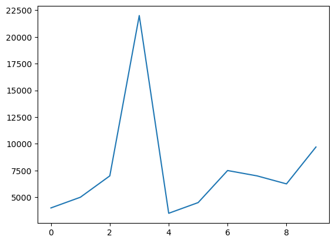

```python
car_sales["Price"].plot()
```